# STAT5003

Week 2: Regression and smoothing

Jaslene Lin

The University of Sydney

# Readings and R functions covered

**Important**

- **Introduction to Statistical Learning**
  - Chapter 2 (Statistical Learning)
  - Chapter 3 (Linear regression)
  - Chapter 7.4 to 7.6 (Smoothing)
- **R** functions
  - `outcome ~ feature1 + feature2` (formulae)
  - `lm` (Linear model)
  - `confint` (confidence intervals)
  - `subset` (argument and function)
  - `predict` (Make predictions from a model)

This presentation is based on the [SOLES reveal.js Quarto template](https://github.com/usyd-soles-edu/soles-revealjs) and is licensed under a [Creative Commons Attribution 4.0 International License](http://creativecommons.org/licenses/by/4.0/).

## Essence of Statistics: Inference

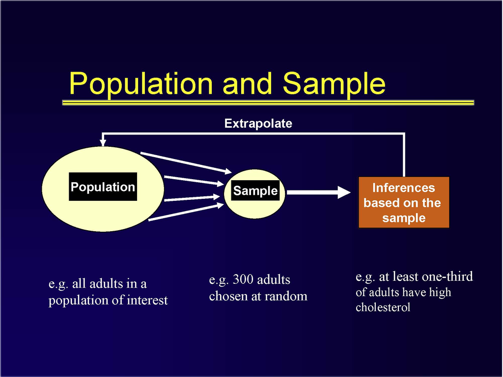

## What Is Statistical Learning?

Statistical learning is a field within statistics that focuses on **building models** to **make predictions or inferences**.

**Supervised Learning**: Given a dataset with features/predictors $(X_{1}, X_{2}, ...X_{p})$ and a target outcome variable $(Y)$, the goal is to learn a **model** $f(X_{1}..X_{p}$) to explain/predict the target.

- example: Is there a relationship between `cholesterol levels` and `age` in the adults’ population?

Depends on the data type of $Y$: numeric or categorical.

- Regression vs. Classification

**Unsupervised learning**: Given a dataset with features $(X_{1}, X_{2}, ...X_{p})$, the goal is to visualise, find patterns, subgroups/clusters within the data.

- example: Can we identify different groups of adults based on their `cholesterol levels` and `ages`?

## Supervised Learning

### Regression

$Y = f(X) + \epsilon$

$\epsilon$ is the **irreducible** error.

The main task is to **use the sample** to estimate $f(X)$.

- Parametric regression:
  - $f(X) = \beta_0 + \beta_1X_{i1} + ... + \beta_p X_{ip}$
- Nonparametric regression:
  - Does not make explicit assumption about the function form about $f(X)$.
  - Assumes $f(X)$ is a *smooth* function that fits the data well.

## Quiz

You are given a dataset containing the number of hours students studied and their corresponding scores on a test.

What is the purpose of using linear regression in this context?

✗To classify students into different groups based on their scores

✗To find the average number of hours students studied

✓To predict the test scores of students based on the number of hours they studied

✗To determine the median test score

## Regression

- Numerically fitting the model is easy

## Regression

[figure not shown]

- BUT knowing how to appropriately fit the model is where you add value

# Line of Best Fit

## The prediction problem

What is the price of a 100 sqm house in St Kilda?

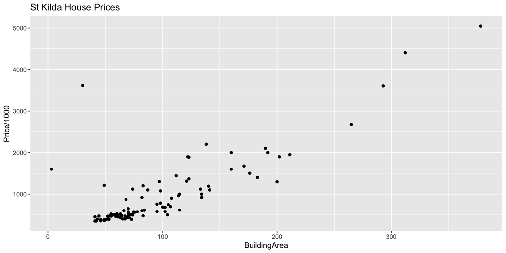

```r
st.kilda.data |> ggplot(aes(x = BuildingArea, y = Price / 1000)) +
  geom_point() + ggtitle("St Kilda House Prices")
```

## The linear regression model

$$\begin{align*}
Y &= f(X) + \varepsilon = \beta_0 + \beta_1 X + \varepsilon\\
& \phantom{=}
\end{align*}$$

- $X$ is the predictor (feature or independent variable)
- $Y$ is the response (target or dependent variable)
- $\beta_0$ is the intercept of the regression line
  - Expected value of $Y$ when $X =0$
- $\beta_1$ is the slope of the regression line
  - mean increase in $Y$ for a *unit* increase in $X$
- $\varepsilon$ is the irreducible or random error
  - Classically assumed to be normally distributed with mean zero and finite variance

## Performance of regression estimates

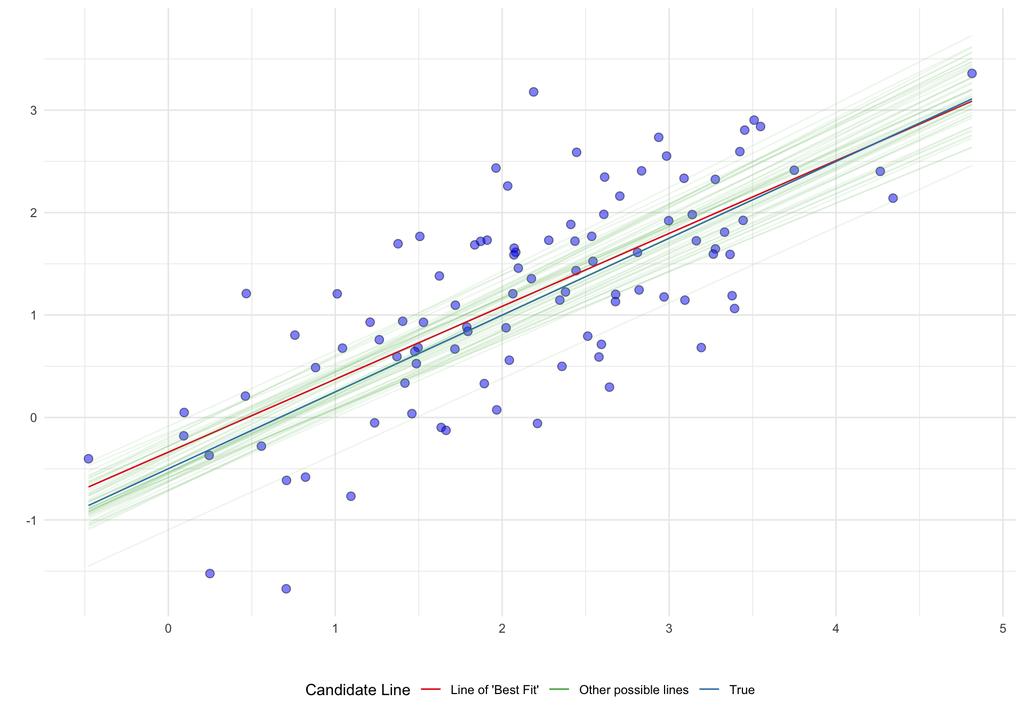

- Data was simulated from model $Y = -0.5 + 0.75X + \varepsilon$
- True line shown in blue
- Standard linear regression fit shown in red
- Why not one of the green lines?

## How to determine the best estimates of $\beta_0 + \beta_1 X$?

- The notion of best needs a **criterion** to measure against.

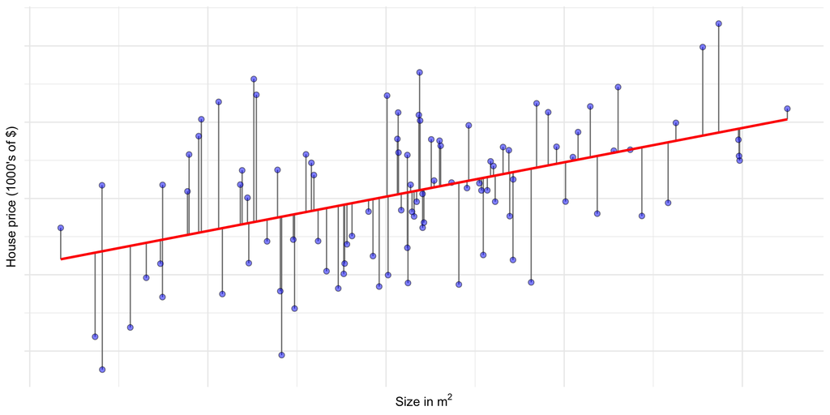

## Least squares equations

- Can show by simple calculus the following:
  - Regression (slope) coefficient: $\displaystyle b_1 = \frac{\sum_{i = 1}^n (x_i - \overline x)(y_i - \overline y)}{\sum_{i = 1}^n (x_i - \overline x)^2} = \frac{\text{Cov}(x, y)}{\text{Var}(x)}$
  - Intercept: $b_0 = \overline y − b_1 \overline x$
  - $\overline x$ and $\overline y$: sample mean of $x_i$ and $y_i$, $i=1,\ldots,n$
- This leads to the estimated regression line:

$$\begin{equation*}
\widehat{y} = \widehat{f(x)} = b_0 + b_1 x
\end{equation*}$$

- Called least squares regression line since it minimises the residual sum of squares
- Under conditions below, the least square estimator is the best linear unbiased estimator
  - Linearity, no multicollinearity, strict exogeneity
  - Normal distributed errors (more generally, spherical errors)

# Basic uses of Simple Linear Regression

## Modelling using `lm`

```r
lm.fit <- lm(Price ~ BuildingArea, data = st.kilda.data)
summary(lm.fit)
```

```
Call:
lm(formula = Price ~ BuildingArea, data = st.kilda.data)

Residuals:
    Min      1Q  Median      3Q     Max
-817415 -201614  -85181   19895 3403199

Coefficients:
              Estimate Std. Error t value Pr(>|t|)
(Intercept)  -129484.0    91775.9  -1.411    0.161
BuildingArea   11209.5      799.8  14.015   <2e-16 ***
---
Signif. codes:  0 '***' 0.001 '**' 0.01 '*' 0.05 '.' 0.1 ' ' 1

Residual standard error: 490300 on 99 degrees of freedom
Multiple R-squared:  0.6649,    Adjusted R-squared:  0.6615
F-statistic: 196.4 on 1 and 99 DF,  p-value: < 2.2e-16
```

## Standard error of sample mean

- Consider a single population estimation problem
  - Wish to estimate some mean, $\mu$, of some random variable $Y$
  - If $Y_1,\ldots,Y_n$ are sampled then $\widehat \mu = \bar Y=\sum_{i=1}^n Y_i/n$ is an estimator of $\mu$ with
    $$\text{Var}(\widehat \mu) = (\text{SE}(\widehat \mu))^2 = \frac{\sigma^2}{n}$$
  - $\sigma^2$ is the variance of $Y$
  - $n$ is the sample size

## Standard error of regression coefficient estimates

- Same concept applies to the regression estimates

$$\begin{align*}
\text{SE}(\widehat{\beta_0}) &= \sigma \sqrt{\frac{1}{n} + \frac{\overline x^2}{\sum_{i = 1}^n (x_i - \overline x)^2}}\\
\text{SE}(\widehat{\beta_1}) &= \frac{\sigma}{\sqrt{\sum_{i = 1}^n (x_i - \overline x)^2}}
\end{align*}$$

where $\sigma^2 = \text{Var}(\varepsilon)$

- As $n \to \infty$, $\text{SE}(\widehat \beta_0) \to 0$ and $\text{SE}(\widehat \beta_1)\to 0$
- Interestingly, if the $x_i$ are more spread out, the standard errors will be smaller
  - more leverage to estimate the parameters

## Using standard errors to compute confidence intervals

```r
summary(lm.fit) # Truncated output with coefficient table
```

```
Call:
lm(formula = Price ~ BuildingArea, data = st.kilda.data)

Residuals:
    Min      1Q  Median      3Q     Max
-817415 -201614  -85181   19895 3403199

Coefficients:
              Estimate Std. Error t value Pr(>|t|)
(Intercept)  -129484.0    91775.9  -1.411    0.161
BuildingArea   11209.5      799.8  14.015   <2e-16 ***
---
Signif. codes:  0 '***' 0.001 '**' 0.01 '*' 0.05 '.' 0.1 ' ' 1

Residual standard error: 490300 on 99 degrees of freedom
Multiple R-squared:  0.6649,    Adjusted R-squared:  0.6615
F-statistic: 196.4 on 1 and 99 DF,  p-value: < 2.2e-16
```

- We can use the standard error to estimate the 95% confidence interval as:
  - $\displaystyle (\widehat \beta_1 - t_{n - 2, 0.975}\text{SE}(\widehat \beta_1), \widehat \beta_1 + t_{n - 2, 0.975}\text{SE}(\widehat \beta_1)) = b_1 \pm t_{n - 2, 0.975} \text{SE}(b_1) = b_1 \pm t_{99, 0.975} \text{SE}(b_1)$
- In our housing example, the 95% confidence interval for the coefficient of `BuildingArea` is [9622.6968, 12796.3032]

$$\begin{align*}
b_1 \pm t_{n - 2, 0.975} \text{SE}(b_1) &= 1.12095\times 10^{4} \pm 1.984 \times 799.8 = (9622.6968, 12796.3032)
\end{align*}$$

## Confidence intervals of regression coefficients

- More directly in `r` code
  - Use the `confint` function

  ```r
  confint(lm.fit)
  ```

  ```
                     2.5 %   97.5 %
  (Intercept)  -311587.233 52619.18
  BuildingArea    9622.491 12796.50
  ```

- This is exact and no precision lost to rounding error
- Easy to change confidence level (99% below)

```r
confint(lm.fit, level = 0.99)
```

```
                  0.5 %    99.5 %
(Intercept)  -370524.63 111556.57
BuildingArea    9108.86  13310.13
```

## Is `BuildingArea` a good predictor of price?

- Whether there is a relationship between `BuildingArea` and price?
- If so, whether such relationship is linear?
- If so, how good is such linear relationship?

```r
summary(lm.fit) # truncated for coefficient table
```

```
Call:
lm(formula = Price ~ BuildingArea, data = st.kilda.data)

Residuals:
    Min      1Q  Median      3Q     Max
-817415 -201614  -85181   19895 3403199

Coefficients:
              Estimate Std. Error t value Pr(>|t|)
(Intercept)  -129484.0    91775.9  -1.411    0.161
BuildingArea   11209.5      799.8  14.015   <2e-16 ***
---
Signif. codes:  0 '***' 0.001 '**' 0.01 '*' 0.05 '.' 0.1 ' ' 1

Residual standard error: 490300 on 99 degrees of freedom
Multiple R-squared:  0.6649,    Adjusted R-squared:  0.6615
F-statistic: 196.4 on 1 and 99 DF,  p-value: < 2.2e-16
```

- Linear regression assumes $Y = \beta_0 + \beta_1 X + \varepsilon$
- If `BuildingArea` is not linearly related to `Price`, then $\beta_1= 0$
- Can conduct a test of significance $H_0: \beta_1 = 0$ against $H_1: \beta_1 \neq 0$
- Can conduct a hypothesis test by computing the $t$-statistic:
  $$t = \frac{\widehat \beta_1 - \beta_1}{\text{SE}(\widehat \beta_1)} \stackrel{H_0}{=} \frac{\widehat \beta_1}{\text{SE}(\widehat \beta_1)}$$

## Is `BuildingArea` a good predictor of price?

```r
summary(lm.fit) # truncated for coefficient table
```

```
Call:
lm(formula = Price ~ BuildingArea, data = st.kilda.data)

Residuals:
    Min      1Q  Median      3Q     Max
-817415 -201614  -85181   19895 3403199

Coefficients:
              Estimate Std. Error t value Pr(>|t|)
(Intercept)  -129484.0    91775.9  -1.411    0.161
BuildingArea   11209.5      799.8  14.015   <2e-16 ***
---
Signif. codes:  0 '***' 0.001 '**' 0.01 '*' 0.05 '.' 0.1 ' ' 1

Residual standard error: 490300 on 99 degrees of freedom
Multiple R-squared:  0.6649,    Adjusted R-squared:  0.6615
F-statistic: 196.4 on 1 and 99 DF,  p-value: < 2.2e-16
```

- Small p-value here suggests that we have strong evidence agains the null hypothesis that there is no relationship between `Price` and `BuildingArea`.

## Quiz

If the slope ( $\beta_1$ ) is found to be statistically insignificant in a regression analysis? What implications does this have for the relationship between ( X ) and ( Y )?

✗There is a strong relationship between ( X ) and ( Y ).

✓There is no evidence of a relationship between ( X ) and ( Y ).

✗The intercept ($\beta_0$ ) is also insignificant.

✗The error term ( $\varepsilon$ ) is normally distributed.

## Assessing the Model Fit–Goodness of fit statistic

- Goodness of fit is measured by the coefficient of determination or ${\color{red}R^2}$

$$\begin{align*}
R^2 &= \frac{\text{Total Sum of Squares} - \text{Residual Sum of Squares}}{\text{Total Sum of Squares}}\\
&= \frac{\sum_{i = 1}^n (y_i - \overline y)^2 - \sum_{i = 1}^n (y_i - \widehat y_i)^2}{\sum_{i = 1}^n (y_i - \overline y)^2}
\end{align*}$$

- $R^2$ is a measure between 0 and 1 for the training dataset
- It measures the proportion of variation in the response $Y$, explained by the linear regression on $X$
  - A value of 0 indicates **none** of the variance in $Y$ can be explained *linearly* by $X$
  - A value of 1 indicates **all** of the variance in $Y$ can be explained *linearly* by $X$
- It is worth mentioning that $R^2$ is **NOT** suggested (or at least not used as the only metric) for evaluating *nonlinear* models (introduced in subsequent weeks)
  - Because Total Sum of Squares is **NOT** the summation of Residual Sum of Squares and Explained Sum of Squares for nonlinear models

```r
round(summary(lm.fit)$r.square, 3)
```

```
[1] 0.665
```

## Linear regression fit

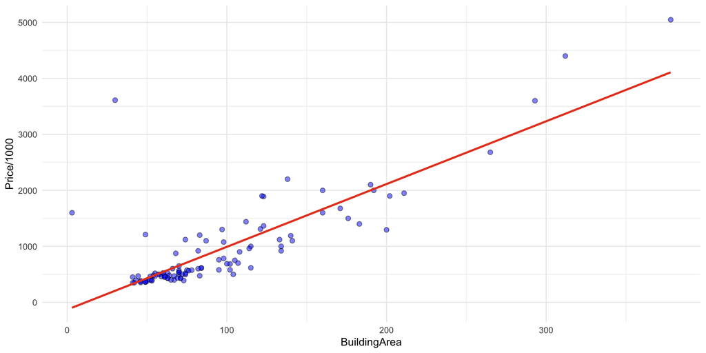

## Estimating the price of a 100 $\text{m}^2$ house in St Kilda

```r
new.100 <- data.frame(BuildingArea = 100)
predict(lm.fit, new.100, interval = "confidence")
```

```
       fit      lwr     upr
1 991465.5 894562.7 1088368
```

```r
predict(lm.fit, new.100, interval = "prediction")
```

```
       fit      lwr     upr
1 991465.5 13820.26 1969111
```

- Confidence interval: how accurately can we predict the **mean price** of a 100 $\text{m}^2$ house in St Kilda
- Prediction interval: how accurately can we predict the **price** of a 100 $\text{m}^2$ house in St Kilda

See more on this [stackoverflow question](https://stats.stackexchange.com/questions/16493/difference-between-confidence-intervals-and-prediction-intervals)

## Fit improvements

- Remove outliers: black line gives overall fit, blue line fit only to blue data (without red points)

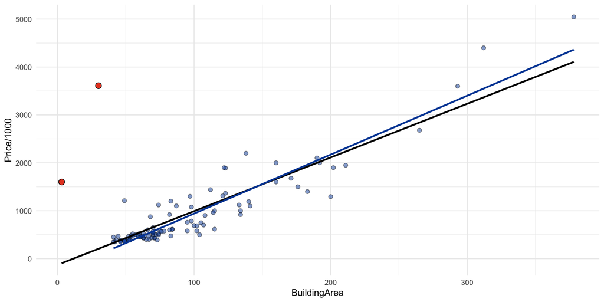

## Linear fit after removing the outliers

```r
lm.without.outliers <- lm(Price / 1000 ~ BuildingArea, data = st.kilda.data, subset = BuildingArea >= 40)
summary(lm.without.outliers)
```

```
Call:
lm(formula = Price/1000 ~ BuildingArea, data = st.kilda.data,
    subset = BuildingArea >= 40)

Residuals:
    Min      1Q  Median      3Q     Max
-876.75 -137.30  -18.27  109.28  896.31

Coefficients:
             Estimate Std. Error t value Pr(>|t|)
(Intercept)  -289.254     57.471  -5.033 2.22e-06 ***
BuildingArea   12.305      0.496  24.807  < 2e-16 ***
---
Signif. codes:  0 '***' 0.001 '**' 0.01 '*' 0.05 '.' 0.1 ' ' 1

Residual standard error: 298.5 on 97 degrees of freedom
Multiple R-squared:  0.8638,    Adjusted R-squared:  0.8624
F-statistic: 615.4 on 1 and 97 DF,  p-value: < 2.2e-16
```

Comparing with the original model

```r
round(summary(lm.fit)$r.square, 3)
```

```
[1] 0.665
```

```r
round(summary(lm.without.outliers)$r.square, 3)
```

```
[1] 0.864
```

# Extending Simple Linear Regression

## Considering more covariates

- What if I have more than one feature (predictor)?
- House prices depend on more than just BuildingArea! What about
  - land area
  - Dwelling type (apartment vs unit vs house vs …)
  - Suburb (location, location, location)

## *R* formulae

- Example formula Response~Predictor1 + Predictor2 + Predictor3
- Left hand side of `~` is the response variable (target to predict)
- Right hand side of `~` are the the predictor variables (features)
- Relationship is assumed to be additive
  - Each additional predictor is added to explain the response $Y = \beta_0 + \beta_1 X_1 + \beta_2 X_2 + \cdots$
- Interaction or multiplicative terms are denoted with `:` and `*`
  - Would be used to define other relationships
  - Example: $Y = \beta_0 + \beta_1 X_1 + \beta_2 X_1 X_2 + \beta_3 X_2 + \cdots$
  - Sometimes it is the case that an interaction term has a very small $p$-value, but the associated main effects do not
  - The hierarchy principle: If we include an interaction in a model, we should also include the main effects, even if the $p$-values associated with their coefficients are not significant

## Multiple linear regression

- Real life problems usually have more than one predictor
  - Simple linear (single variable) regression can be extended to multiple predictors

$$Y = \beta_0 + \beta_1 X_1 + \beta_2 X_2 + \beta_3 X_3 + \cdots + \beta_p X_p + \varepsilon$$

- The interpretation is the $\beta_p$ coefficient denotes the average increase/decrease in $Y$ for each single unit increase in $X_p$, holding all the other predictors fixed
- **Claims of causality** should be avoided for observational data

## Extending the house prediction model to multiple features

- Perhaps 100 $\text{m}^2$ houses cost more than 100 $\text{m}^2$ units?

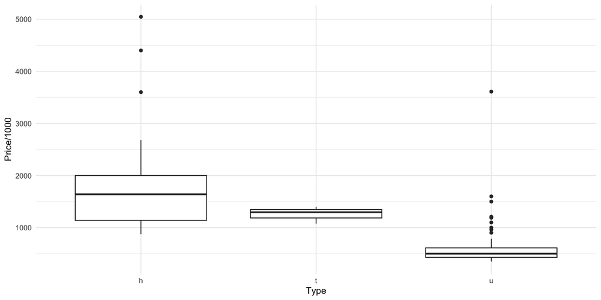

## Multiple regression with `lm`

```r
multi.lm <- lm(Price / 1000 ~ Type + BuildingArea, data = st.kilda.data)
summary(multi.lm)
```

```
Call:
lm(formula = Price/1000 ~ Type + BuildingArea, data = st.kilda.data)

Residuals:
   Min     1Q Median     3Q    Max
-700.3 -173.1  -65.9   18.6 3389.6

Coefficients:
             Estimate Std. Error t value Pr(>|t|)
(Intercept)   342.865    186.764   1.836  0.06945 .
Typet        -613.953    286.272  -2.145  0.03448 *
Typeu        -408.417    139.915  -2.919  0.00436 **
BuildingArea    9.533      1.014   9.398 2.68e-15 ***
---
Signif. codes:  0 '***' 0.001 '**' 0.01 '*' 0.05 '.' 0.1 ' ' 1

Residual standard error: 469.5 on 97 degrees of freedom
Multiple R-squared:  0.6989,    Adjusted R-squared:  0.6896
F-statistic: 75.06 on 3 and 97 DF,  p-value: < 2.2e-16
```

## Model interpretation

```r
summary(multi.lm)
```

```
Call:
lm(formula = Price/1000 ~ Type + BuildingArea, data = st.kilda.data)

Residuals:
   Min     1Q Median     3Q    Max
-700.3 -173.1  -65.9   18.6 3389.6

Coefficients:
             Estimate Std. Error t value Pr(>|t|)
(Intercept)   342.865    186.764   1.836  0.06945 .
Typet        -613.953    286.272  -2.145  0.03448 *
Typeu        -408.417    139.915  -2.919  0.00436 **
BuildingArea    9.533      1.014   9.398 2.68e-15 ***
---
Signif. codes:  0 '***' 0.001 '**' 0.01 '*' 0.05 '.' 0.1 ' ' 1

Residual standard error: 469.5 on 97 degrees of freedom
Multiple R-squared:  0.6989,    Adjusted R-squared:  0.6896
F-statistic: 75.06 on 3 and 97 DF,  p-value: < 2.2e-16
```

```r
multi.pred.data <- data.frame(BuildingArea = rep(100, 3), Type = c("u", "t", "h"))
predict(multi.lm, newdata = multi.pred.data)
```

```
        1         2         3
 887.7252  682.1894 1296.1427
```

# Nonparametric regression or Smoothing

## Parametric vs non-parametric methods

- **Parametric methods** involve selecting a statistical model (e.g. linear regression model) and fitting the parameters of the model (e.g. slope, intercept) using the training data
- **Nonparametric methods** don’t require selecting a strict model. The data is allowed to *speak for itself*. However, don’t have easily interpretable parameters

## Data smoothing

With **predictor-response** data, the random response variable $Y$ is assumed to be a **non-linear** function of the predictor variable $X$:
$$Y = f(X) + \varepsilon$$
$f$ is some fixed, non-linear smooth function. $X$ and $Y$ are iid copies of $X$ and $Y$. $\varepsilon$ is a zero-mean random variable. Smoothing is a **non-parametric method** to estimate $f$.

## Local averaging

- Most smoothers (smoothing functions) rely on the concept of *local averaging*
  - In contrast, simple linear regression attempts to fit the best global line.
- Example: Suppose you want to determine the expectation of response $Y$ conditional on $X=x$
  - The $Y$ whose corresponding $X=x$ are near $x$ should be averaged with higher weight to attempt to estimate $f(x)$.
- A generic local-averaging smoother can be written as
  $$\widehat f(x) = \text{average} \left( Y | x \in N(x) \right)$$
  - $\text{average}$ is some generalised averaging operation.
  - $N(x)$ is some neighbourhood of $x$.

## $k$-nearest neighbours and constant-span running mean

- A simple smoother takes the sample mean of $k$ nearby points
- We define $N(x)$ as $x$ itself, the $(k-1)/2$ points whose predictor values are nearest below $x$, and the $(k-1)/2$ points whose predictor values are nearest above $x$
- This neighbourhood is termed the *symmetric nearest neighbourhood*, and the smoother is called a **moving average** or a **k****-nearest neighbours (kNN) smoother**
- The constant-span running-mean smoother can be written as:
  $$\widehat f(x) = \text{mean} \left[ Y_j \text{ such that} \max \left(i - \frac{k - 1}{2}, 1 \right)\le j \le \min \left(i + \frac{k - 1}{2} , n\right) \right]$$

## Regression splines

- Fit piece-wise functions, where each function can be a $d$-dimensional polynomial function
- Constrain the function to be smooth and continuous
- **Cubic spline** fits cubic polynomial functions, with the constraints:
  - continuous at each knot, continuity of the 1st derivative and continuity of the 2nd derivative
- Advantage of the cubic spline is that the curve looks smooth to the eye, and can be used to fit almost any function.

## Loess

- Loess is a Locally weighted scatter plot smoothing method.
- The **loess (LOcal regrESSion) smoother** is a widely used method with good robustness properties.
- It is essentially a weighted running-line smoother, except that each local line is fitted using a robust method rather than least squares.
- As a result, the smoother is nonlinear.
- **Loess is computationally intensive and require densely sampled data.**
- *The `span` parameter in the `loess` or `geom_smooth` functions control the degree of smoothing. A larger span results in more smoothing (less sensitive to local variations).*

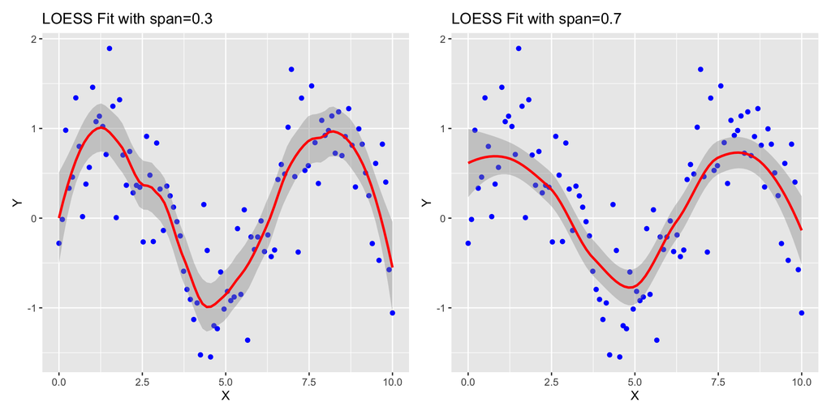

```r
# Load necessary library
library(ggplot2)
library(patchwork)

# Generate sample data
set.seed(123) # Setting seed for reproducibility
x <- seq(0, 10, length.out = 100)
y <- sin(x) + rnorm(100, sd = 0.5)
data <- data.frame(x = x, y = y)

# Plot with span = 0.3
plot1 <- ggplot(data, aes(x = x, y = y)) +
  geom_point(color = "blue") +
  geom_smooth(method = "loess", span = 0.3, color = "red") +
  ggtitle("LOESS Fit with span=0.3") +
  xlab("X") +
  ylab("Y")

# Plot with span = 0.7
plot2 <- ggplot(data, aes(x = x, y = y)) +
  geom_point(color = "blue") +
  geom_smooth(method = "loess", span = 0.7, color = "red") +
  ggtitle("LOESS Fit with span=0.7") +
  xlab("X") +
  ylab("Y")

plot1 + plot2
```

## Local regression

- Fitting local linear fits that are weighted.
- Formula for local constant fit is $\widehat f(x) = \frac{\sum_{i = 1}^n Y K((X-x)/h)}{\sum_{i = 1}^n K((X-x)/h)}$, where $K$ is a kernel.

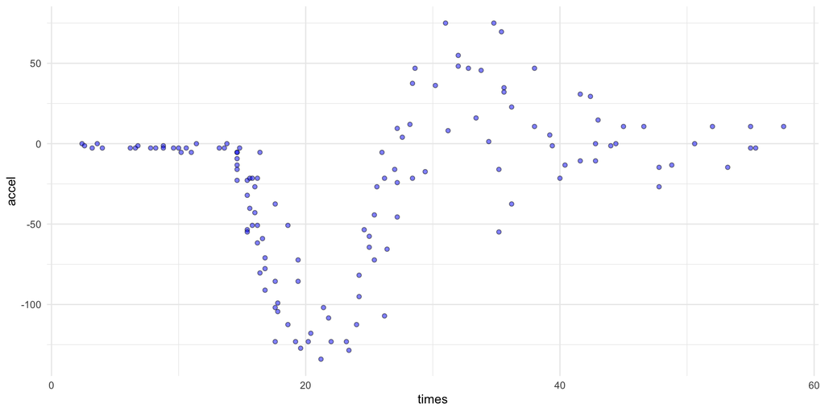

## Local regression animation

- Using a large averaging window

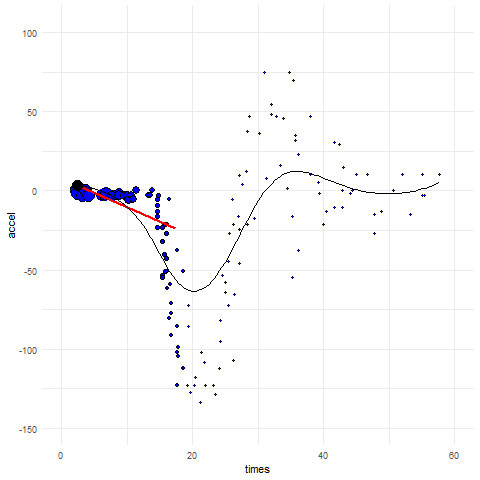

- Using a smaller averaging window

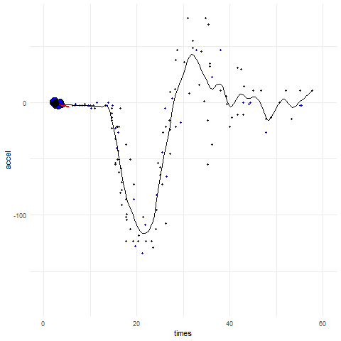

## Nonparametric smoothing vs linear regression

- Advantages of non-parametric smoothing
  - Can model non-linear functions (e.g. splines, loess)
  - Does not make any assumption about the functional form of the data
- Advantages of linear regression
  - Computationally efficient, even for multivariate linear regression
  - Model is interpretable, i.e. one can know the statistical meaning of the estimated slope parameters